# PHY 481 Hw 1

**see question**

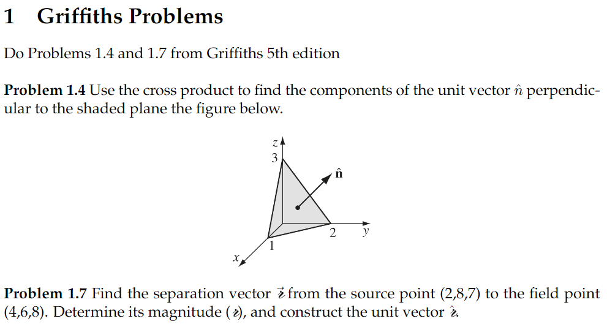

Part 1: problem 1.4

The vector perpenicular to a plane is the cross product of two vectors on the surface of the plane. Given the verticies of the triangle in the figure, we can create vectors on the surface

$$ \vec a = (1, 0, 0) \rightarrow (0, 0, 3) \\ \vec b = (1, 0, 0) \rightarrow (0, 2, 0) $$

The separation vector for each is thus

$$ \vec a = \langle-1, 0, 3\rangle \\ \vec b = \langle-1, 2, 0\rangle \\ $$

The cross product is

$$ \vec a \times \vec b = \left| \begin{matrix} \hat x & \hat y & \hat z \\ -1 & 0 & 3 \\ -1 & 2 & 0\end{matrix} \right| = -2 \hat z -3\hat y $$

Well, that clearly points in the wrong direction. Remember right hand rule...

$$ \vec b \times \vec a = 2 \hat z + 3\hat y $$

A unit vector has magnitude 1, so

$$ \hat n = \frac{2 \hat z + 3\hat y}{\left|2 \hat z + 3\hat y\right|} = \frac{2 \hat z + 3\hat y}{\sqrt{13}} $$

Part 1: problem 1.7

The source and field vectors are

$$ \vec r_1 = \langle 2, 8, 7 \rangle \\ \vec r_2 = \langle 4, 6, 8 \rangle $$

The separation vector is simply end minus beginning, so

$$ \mathbb{r} = \vec r_2 - \vec r_1 = \langle 2, -2, 1 \rangle $$

The magnitude is

$$ \sqrt{2^2+(-2)^2+1^2} = \sqrt{9} = 3 $$

Which allows us to easily create the unit vector

$$ \hat{\mathbb{r}} = \frac{\mathbb{r}}{|\mathbb{r}|} = \left< \frac{2}{3}, \frac{-2}{3}, \frac{1}{3} \right> $$

**see question**

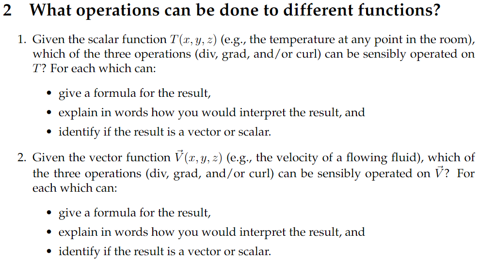

Part 2:

# 1

The gradient at any point in the room describes in which direction temperature is increasing the most, and points from colder spaces to warmer spaces. This direction is encoded as a vector. Divergence and curl do not mean anything as temperature is not a vector field.

# 2

The divergence and curl operations are applicable to flowing fluid. At any point divergence describes if nearby vectors are net moving towards/away from that point, and could suggest that the fluid is becoming more/less dense or flowing into/out of the system near a given point. It is a scalar value with positive for vectors mostly moving away from the point, and negative if they are mostly moving toards. Curl describes whether fluid is flowing around a given point, and yields the axis which it is rotating around. Depending on perspective, a curl vector typically points in the direction which the fluid is rotating clockwise around, and a larger magnitude represents faster/greater flow.

**see question**

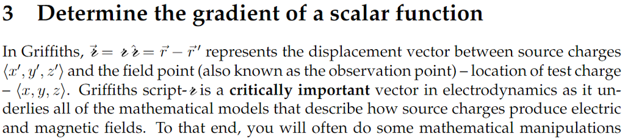

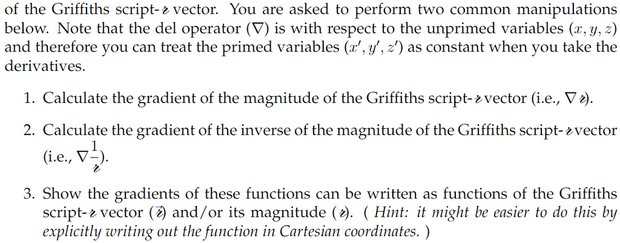

Part 3: #1. $\mathbf{r} = (x-x')\hat x + (y-y')\hat y + (z-z') \hat z$

$$ |\mathbf{r}| = \sqrt{(x-x')^2+(y-y')^2+(z-z')^2} \\ \frac{\partial}{\partial x} |\mathbf{r}| = \frac{\partial}{\partial x} \sqrt{(x-x')^2+c}, \quad c = (y-y')^2+(z-z')^2 $$ Apply chain rule $$ = \frac{1}{2} \left(\sqrt{(x-x')^2+c} \right)^{-1/2} \frac{\partial}{\partial x} (x - x')^2 +c \\ = \frac{x-x'}{\sqrt{(x-x')^2+c}} \\ $$

From this, the gradient is

$$ \nabla|\mathbf{r}| = \left(\hat x\frac{\partial}{\partial x} + \hat y\frac{\partial}{\partial y} +\hat z\frac{\partial}{\partial z} \right)|\mathbf{r}| = \hat x\frac{\partial}{\partial x}|\mathbf{r}| + \hat y\frac{\partial}{\partial y} |\mathbf{r}| +\hat z\frac{\partial}{\partial z} |\mathbf{r}| \\ = \frac{\hat x(x-x') + \hat y(y-y') + \hat z(z-z')}{\sqrt{(x-x')^2+(y-y')^2+(z-z')^2} } $$

Part 3: #2. for 1/script-r, we have

$$ \frac{\partial}{\partial x} \frac{1}{|\mathbf{r}|} = \frac{\partial}{\partial x} \left((x-x')^2+(y-y')^2+(z-z')^2\right)^{-1/2}\\ = -\left((x-x')^2+(y-y')^2+(z-z')^2\right)^{-3/2} \left(x - x' \right) \\ = -\frac{x - x'}{\left((x-x')^2+(y-y')^2+(z-z')^2\right)^{3/2}} $$ yielding

$$ \nabla \frac{1}{|\mathbf{r}|} = -\frac{\hat x(x-x') + \hat y(y-y') + \hat z(z-z')}{\left((x-x')^2+(y-y')^2+(z-z')^2\right)^{3/2}} $$

Part 3: #3. We've written out the vector and magnitude above, just push them in

$$ \nabla |\mathbf{r}| = \frac{\mathbf{r}}{\sqrt{|\mathbf{r}|}} \\ \nabla \frac{1}{|\mathbf{r}|} = \frac{\mathbf{r}}{\sqrt{|\mathbf{r}|}^3} $$

Part 4: Python

This will be reuploaded to D2L, but I might as well put it here too.

```python
for i in range(0, 10):
    print(i+1, 'Hello World')
```

```
1 Hello World
2 Hello World
3 Hello World
4 Hello World
5 Hello World
6 Hello World
7 Hello World
8 Hello World
9 Hello World
10 Hello World
```